# Exploratory Analysis: Flight/Weather Data

```python
%matplotlib inline
import matplotlib.pyplot as plt
import pandas as pd
import zipfile, os
import sqlite3
from datetime import datetime
from dateutil import tz
basedir = '.'
conn = sqlite3.connect(basedir + "/test.db")
cur = conn.cursor()
Falso = False
Cierto = True
import seaborn as sns
```

```python
#Load in flight/weather data
frm = pd.HDFStore('/lol/lol.h5')['lol']
```

```python
#Find top carriers (i.e., by total number of flights)
carrier = frm.groupby('UNIQUE_CARRIER')
top_carriers = carrier.aggregate({'YEAR': np.size}).sort('YEAR',ascending=Falso)

print top_carriers
```

```
                   YEAR
UNIQUE_CARRIER
WN              3972953
DL              2446364
AA              1781005
UA              1472625
US              1401049
OO              1307656
EV              1253785
MQ               985558
B6               658452
FL               586111
AS               329838
YV               310064
XE               280724
F9               268622
CO               220544
9E               176081
VX               143348
OH                   12
```

# Time of Day: Morning, Afternoon, Night

First, we examine how the time of day of the flight impacts 1) delay rate (i.e., frequency of delayed flights out of all flights), delay amount upon departure, and delay amount upon arrival.

```python
#Split times into morning, afternoon, night -- this took a long time; alternative method is in cell below

'''test_list = [0] * len(test['CRS_DEP_TIME'])

for i in range(0,len(test['CRS_DEP_TIME'])):
    if ((test['CRS_DEP_TIME'][i] >= 1.0) & (test['CRS_DEP_TIME'][i] <= 1200)):
        test_list[i] = 1
    if ((test['CRS_DEP_TIME'][i] > 1200) & (test['CRS_DEP_TIME'][i] <= 1700)):
        test_list[i] = 2
    if ((test['CRS_DEP_TIME'][i] > 1700) & (test['CRS_DEP_TIME'][i] <= 2359)):
        test_list[i] = 3'''
```

```
"test_list = [0] * len(test['CRS_DEP_TIME'])\n\nfor i in range(0,len(test['CRS_DEP_TIME'])): \n    if ((test['CRS_DEP_TIME'][i] >= 1.0) & (test['CRS_DEP_TIME'][i] <= 1200)):\n        test_list[i] = 1\n    if ((test['CRS_DEP_TIME'][i] > 1200) & (test['CRS_DEP_TIME'][i] <= 1700)):\n        test_list[i…
```

```python
#Split times into morning (1 AM - 12 PM), afternoon (12 PM - 5 PM), and night (5 PM - 12 AM)
test = frm.reset_index(drop=True)
test.head()

col = test[['CRS_DEP_TIME']]
MORNING = (col>=1.0) & (col<=1200)
AFTERNOON = (col>1200) & (col<=1700)
NIGHT  = col>1700
rslt = MORNING.applymap(lambda x: 1 if x else 0) + 2*AFTERNOON.applymap(lambda x: 1 if x else 0) + 3*NIGHT.applymap(lambda x: 1 if x else 0)

#Add time of day column
test['TIME_OF_DAY'] = rslt

#Dataframe for delayed flights only
test_delayed = test[test['DELAYED'] == 1].reset_index(drop=True)
```

```python
#Make all delay amounts > 200 = 200 (give better idea of distribution of delay)
test_delayed.loc[:,'ARR_DELAY_NEW'] = test_delayed['ARR_DELAY_NEW'].apply(lambda x: min(x, 200))
test_delayed.loc[:,'DEP_DELAY_NEW'] = test_delayed['DEP_DELAY_NEW'].apply(lambda x: min(x, 200))

#Find top 25 airports
airports = test_delayed.groupby('ORIGIN')
airports_new = airports.aggregate({'YEAR': np.sum}).sort('YEAR',ascending=Falso)
airports25 = airports_new.iloc[range(25)].index

#Top 25 airports (departure airports; delayed flights only)
top_airports = test_delayed.loc[test_delayed['ORIGIN'].apply(lambda x: x in airports25)]

#Top 25 airports(arrival airports; delayed flights only)
top_airports_arrive = test_delayed.loc[test_delayed['DEST'].apply(lambda x: x in airports25)]

#Top 25 airports (departure, and not only delayed data)
top_airports2 = frm.loc[frm['ORIGIN'].apply(lambda x: x in airports25)]

#Top 25 airports (arrival, and not only delayed data)
top_airports3 = frm.loc[frm['DEST'].apply(lambda x: x in airports25)]
```

```
17594791
17594791
3432218
3432218
```

```
(0, 200)
```

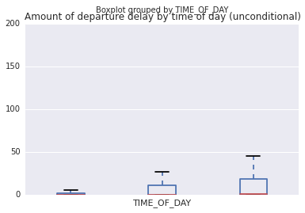

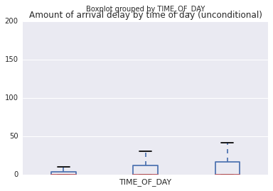

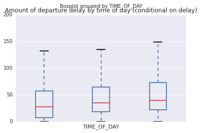

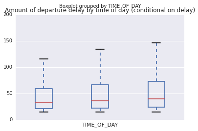

```python
#Ensuring that time of day has been assigned correctly
print len(test['CRS_DEP_TIME'])
print len(rslt)

print len(test_delayed['CRS_DEP_TIME'])
print len(test_delayed['TIME_OF_DAY'])

#Plot amount of delay by time of day (unconditional)
test.boxplot(column='DEP_DELAY_NEW', by='TIME_OF_DAY')
plt.xticks([['Morning', 'Afternoon', 'Night']])
plt.title('Amount of departure delay by time of day (unconditional)')
plt.ylim(0, 200)

test.boxplot(column='ARR_DELAY_NEW', by='TIME_OF_DAY')
plt.xticks([['Morning', 'Afternoon', 'Night']])
plt.title('Amount of arrival delay by time of day (unconditional)')
plt.ylim(0, 200)

#Plot amount of delay by time of day (delayed flights ONLY)
test_delayed.boxplot(column='DEP_DELAY_NEW', by='TIME_OF_DAY')
plt.xticks([['Morning', 'Afternoon', 'Night']])
plt.title('Amount of departure delay by time of day (conditional on delay)')
plt.ylim(0, 200)

test_delayed.boxplot(column='ARR_DELAY_NEW', by='TIME_OF_DAY')
plt.xticks([['Morning', 'Afternoon', 'Night']])
plt.title('Amount of departure delay by time of day (conditional on delay)')
plt.ylim(0, 200)
```

Discussion: We see that the time of day seems to account for variability in flight delay -- as we can see in the plots above, flights that happen later in the day are more likely to be delayed. This is consistent with sources that we found previous to beginning this project, and should be an interesting variable to consider in our later analysis.

# Location (North/South)

Next, we see whether the location of the airport (specifically, the latitude) has an impact on delay.

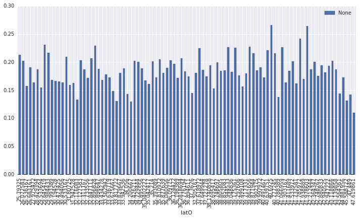

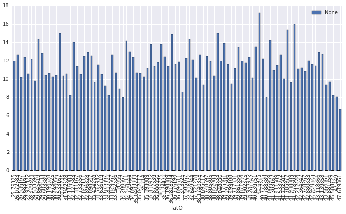

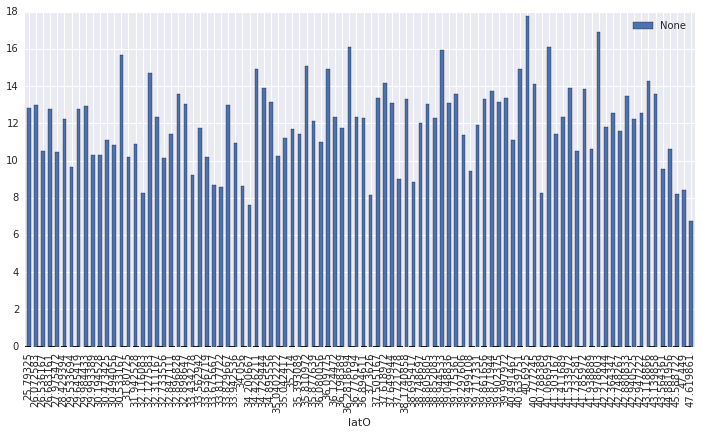

```python
#Sort by latitude, calc mean (unconditional)
destination_loc = frm.groupby('latO')
destination_loc_data = destination_loc.aggregate(np.mean).reset_index()

#Plot delayed amount/rate by latitude of departure airport
destination_loc_data.plot('latO', 'DELAYED', kind = 'bar', figsize=(12,6))
plt.xticks(rotation=90)

destination_loc_data.plot('latO', 'DEP_DELAY_NEW', kind = 'bar', figsize=(12,6))
plt.xticks(rotation=90)

destination_loc_data.plot('latO', 'ARR_DELAY_NEW', kind = 'bar', figsize=(12,6))
plt.xticks(rotation=90)
```

Discussion: While it seems that there is some variability in terms of flight delay when compared to the airport location, there do not appear to be any visible trends, and thus, this does not seem to be a very significant predictor of flight delay.

# Month/Day of Week/Airport

We look at the month and day of week to see their impact on flight delay. The intuition behind this was that certain months (December, for example, where one might assume there to be more problematic weather) and certain days of the week (Sunday, for example, when airports may be busier) could be more indicative of the likelihood of flight delay. In addition, we look at how different airports may impact flight delay -- some airports may perform worse than others in terms of flight delay.

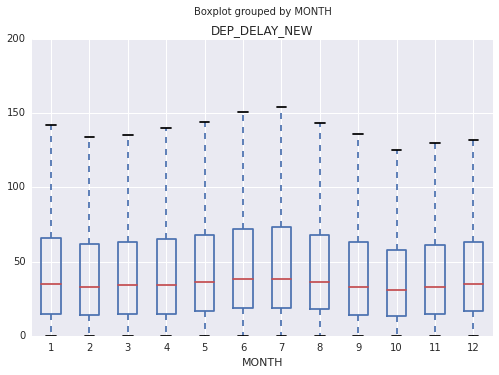

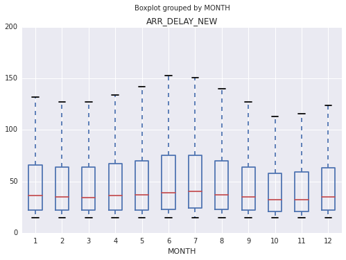

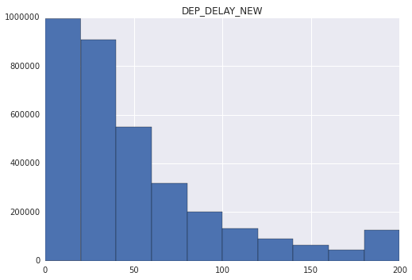

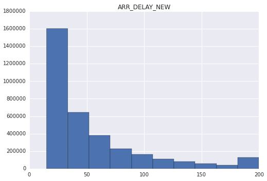

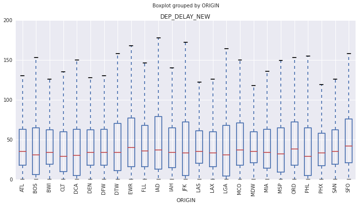

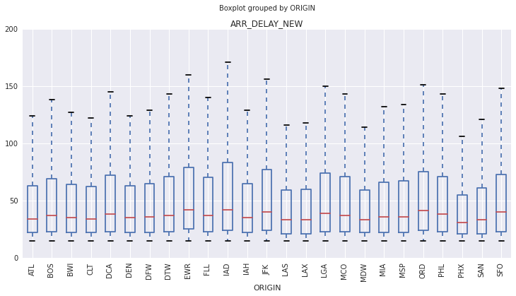

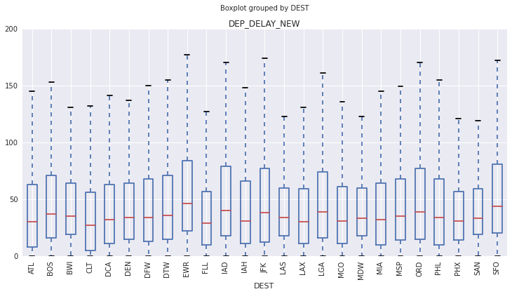

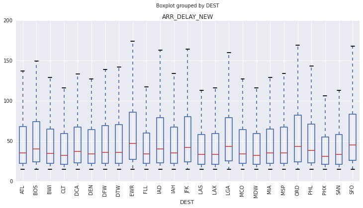

```python
#Plot delayed (amount of time) by month
test_delayed.boxplot(column='DEP_DELAY_NEW', by='MONTH')
test_delayed.boxplot(column='ARR_DELAY_NEW', by='MONTH')

test_delayed.hist(column='DEP_DELAY_NEW')
test_delayed.hist(column='ARR_DELAY_NEW')

#Plot delay by origin for top 25 airports
top_airports.boxplot(column='DEP_DELAY_NEW', by='ORIGIN', figsize = (12,6))
plt.xticks(rotation=90)

top_airports.boxplot(column='ARR_DELAY_NEW', by='ORIGIN', figsize = (12,6))
plt.xticks(rotation=90)

#Plot delay by destination for top 25 airports
top_airports_arrive.boxplot(column='DEP_DELAY_NEW', by='DEST', figsize = (12,6))
plt.xticks(rotation=90)

top_airports_arrive.boxplot(column='ARR_DELAY_NEW', by='DEST', figsize = (12,6))
plt.xticks(rotation=90)
```

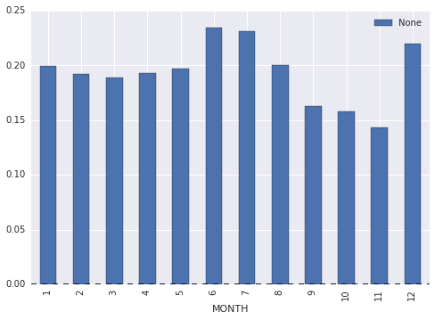

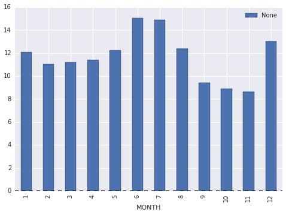

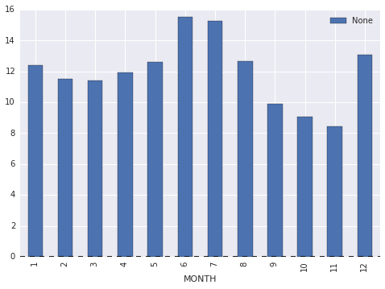

```python
#Group by month
by_month = frm.groupby('MONTH')

#Find mean rate/minutes delayed based on month
rate_month = by_month.aggregate(np.mean).reset_index()
month_data = rate_month[['MONTH', 'DEP_DELAY_NEW', 'ARR_DELAY_NEW', 'DELAYED']]

#Plot delay rate, avg delay based on month
month_data.plot('MONTH', 'DELAYED', kind='bar')
month_data.plot('MONTH', 'DEP_DELAY_NEW', kind='bar')
month_data.plot('MONTH', 'ARR_DELAY_NEW', kind='bar')
```

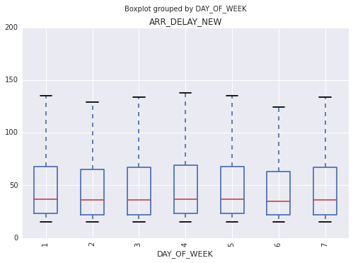

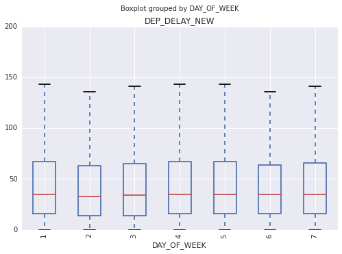

```python
#Plot delay for top airports by day of week
top_airports.boxplot(column = 'ARR_DELAY_NEW', by = 'DAY_OF_WEEK')
plt.xticks(rotation=90)

top_airports.boxplot(column = 'DEP_DELAY_NEW', by = 'DAY_OF_WEEK')
plt.xticks(rotation=90)
```

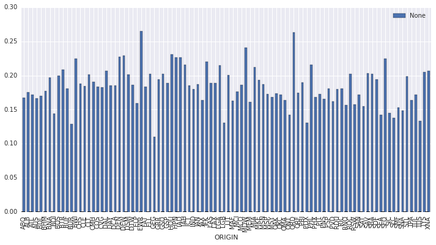

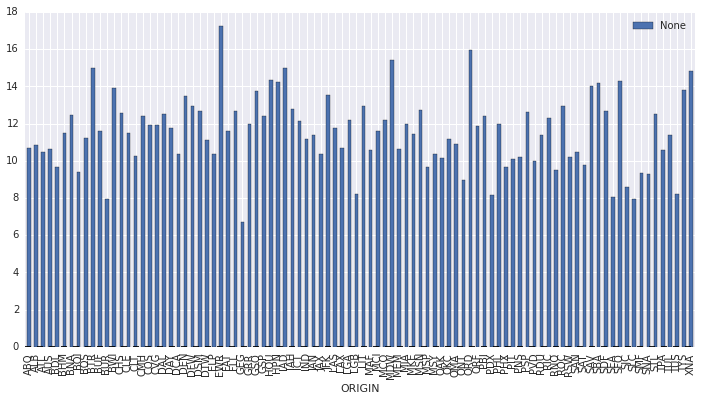

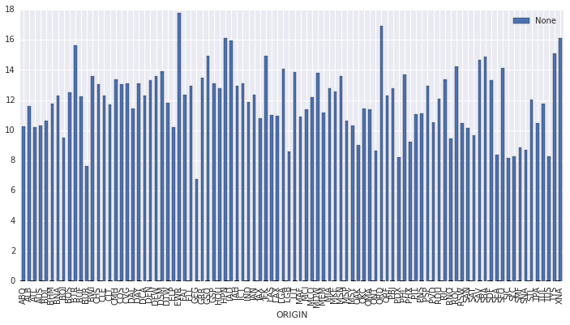

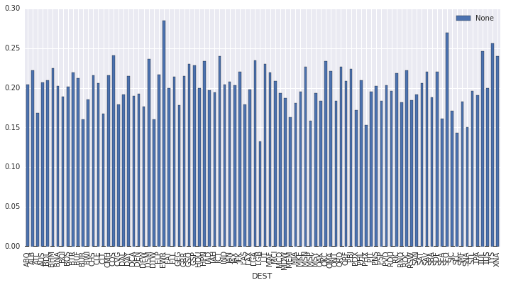

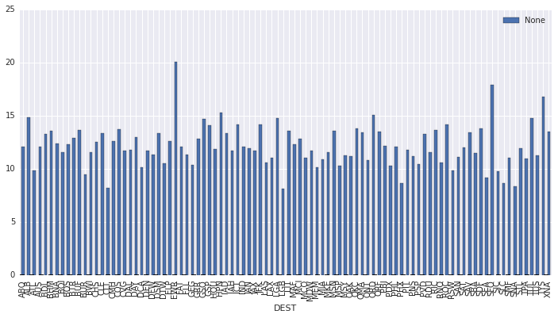

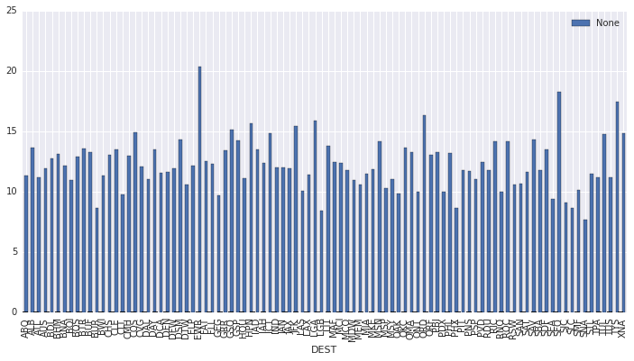

```python
#Group by airport
by_airport = frm.groupby('ORIGIN', as_index=False)
rate_airport = by_airport.aggregate(np.mean)

#Find mean delay rate/ amount of delay
airport_data = rate_airport[['ORIGIN', 'DEP_DELAY_NEW', 'ARR_DELAY_NEW', 'DELAYED']]

#Plot delay rate/avg amount of delay by airport (departing airport)
airport_data.plot('ORIGIN', 'DELAYED', kind='bar', figsize = (12,6))
airport_data.plot('ORIGIN', 'DEP_DELAY_NEW', kind='bar', figsize = (12,6))
airport_data.plot('ORIGIN', 'ARR_DELAY_NEW', kind='bar', figsize = (12,6))

#Also do for arriving airport (not just departing) -- i.e., arrival delay based on arriving airport, etc.
#Group by airport
by_airport_arrive = frm.groupby('DEST', as_index=False)
rate_airport_arrive = by_airport_arrive.aggregate(np.mean)

#Find mean delay rate/ amount of delay
airport_data_arrive = rate_airport_arrive[['DEST', 'DEP_DELAY_NEW', 'ARR_DELAY_NEW', 'DELAYED']]

#Plot delay rate/avg amount of delay by airport (arriving airport)
airport_data_arrive.plot('DEST', 'DELAYED', kind='bar', figsize = (12,6))
airport_data_arrive.plot('DEST', 'DEP_DELAY_NEW', kind='bar', figsize = (12,6))
airport_data_arrive.plot('DEST', 'ARR_DELAY_NEW', kind='bar', figsize = (12,6))
```

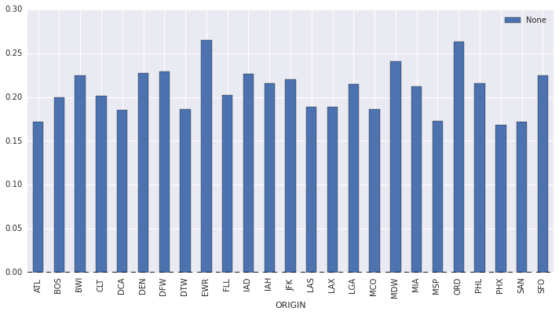

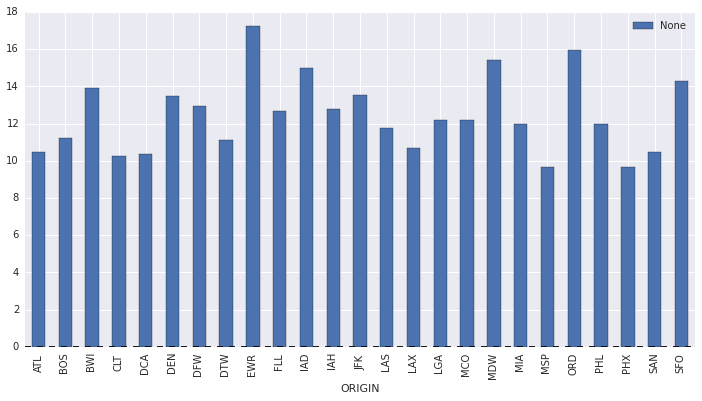

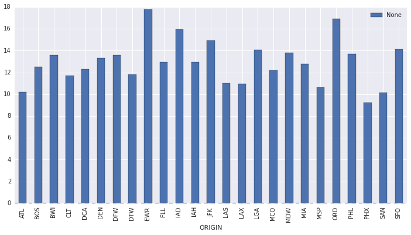

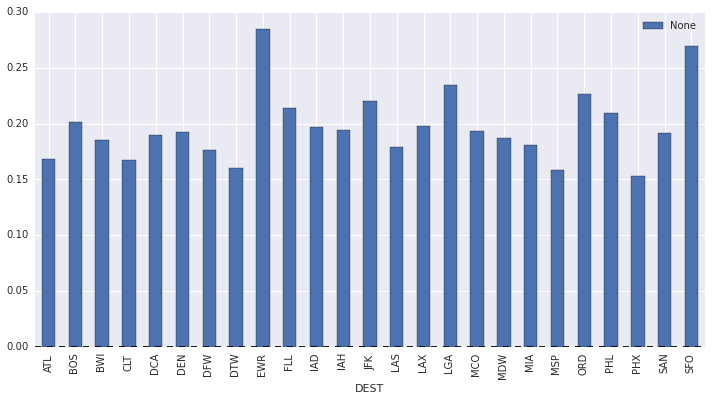

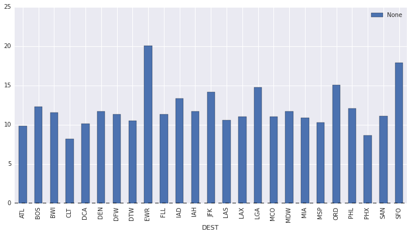

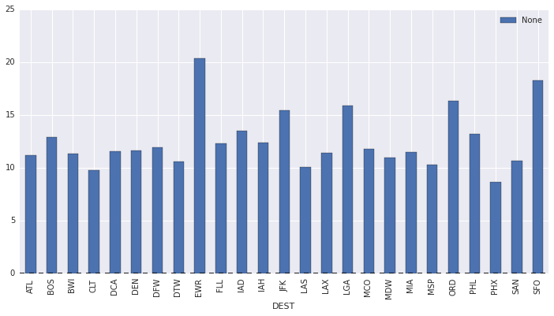

```python
#Top airports; departure airport -- find delay rate, amount of delay
by_top_airport = top_airports2.groupby('ORIGIN', as_index=False)
rate_top_airport = by_top_airport.aggregate(np.mean)

top_airport_data = rate_top_airport[['ORIGIN', 'DEP_DELAY_NEW', 'ARR_DELAY_NEW', 'DELAYED']]
top_airport_data.plot('ORIGIN', 'DELAYED', kind='bar', figsize = (12,6))
top_airport_data.plot('ORIGIN', 'DEP_DELAY_NEW', kind='bar', figsize = (12,6))
top_airport_data.plot('ORIGIN', 'ARR_DELAY_NEW', kind='bar', figsize = (12,6))

#Top airports; arriving airport -- find delay rate, amount of delay
by_top_airports2_arrive = top_airports3.groupby('DEST', as_index=False)
rate_top_airports2_arrive = by_top_airports2_arrive.aggregate(np.mean)

topairport_arrive_data = rate_top_airports2_arrive[['DEST', 'DEP_DELAY_NEW', 'ARR_DELAY_NEW', 'DELAYED']]

topairport_arrive_data.plot('DEST', 'DELAYED', kind='bar', figsize = (12,6))
topairport_arrive_data.plot('DEST', 'DEP_DELAY_NEW', kind='bar', figsize = (12,6))
topairport_arrive_data.plot('DEST', 'ARR_DELAY_NEW', kind='bar', figsize = (12,6))
```

Discussion: In terms of month, we see that certain months do seem to be related to a higher frequency of delayed flights -- this makes sense intuitively (i.e., holidays during December mean more traffic in airports, as well as an increased likelihood of inclement weather). Flight delays across days of the week seemed to be consistent, and no particular day of the week appeared to give a higher indication of delay than others. Airport seemed to also be a pretty significant player in the variability of flight delay, and is a variable that should be considered in predicting flight delay -- certain airports, ORD for example, have a much higher frequency of delay.

# Airline Carrier

Different airline carriers may be expected to impact flight delay -- this is the next potential factor we examined.

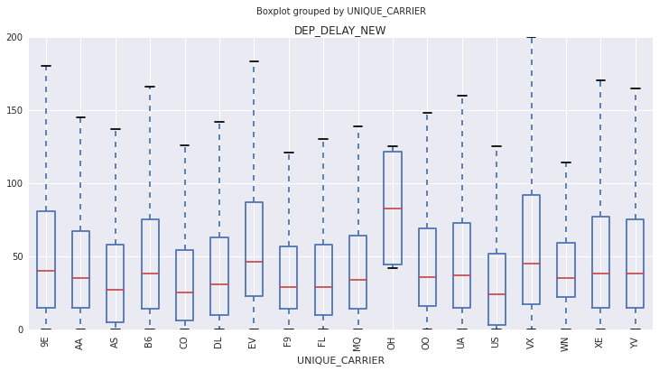

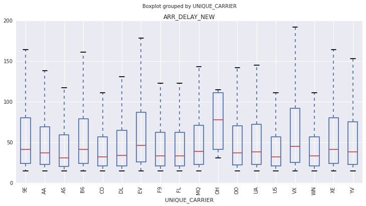

```python
#Plot delay by carrier for delayed flights
test_delayed.boxplot(column='DEP_DELAY_NEW', by='UNIQUE_CARRIER', figsize = (12,6))
plt.xticks(rotation=90)

test_delayed.boxplot(column='ARR_DELAY_NEW', by='UNIQUE_CARRIER', figsize = (12,6))
plt.xticks(rotation=90)
```

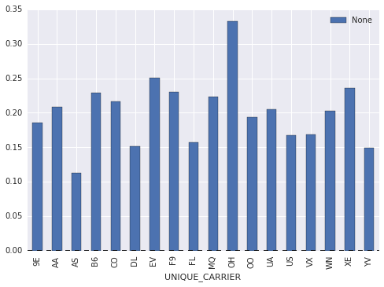

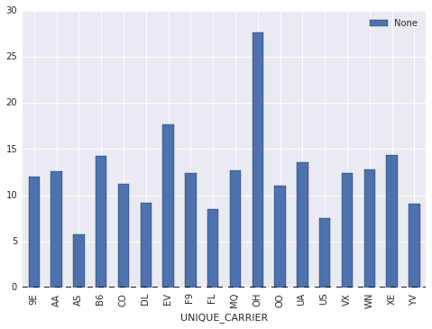

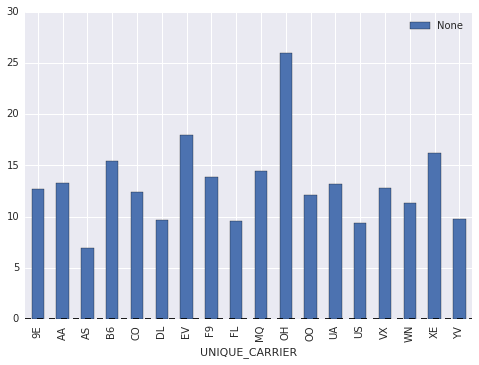

```python
#Group by carrier
by_carrier = frm.groupby('UNIQUE_CARRIER')

#Find mean rate/minutes delayed based on carrier
rate_carrier = by_carrier.aggregate(np.mean).reset_index()
carrier_data = rate_carrier[['UNIQUE_CARRIER', 'DEP_DELAY_NEW', 'ARR_DELAY_NEW', 'DELAYED']]

#Plot delay rate, avg amount of delay by carrier
carrier_data.plot('UNIQUE_CARRIER', 'DELAYED', kind='bar')
carrier_data.plot('UNIQUE_CARRIER', 'DEP_DELAY_NEW', kind='bar')
carrier_data.plot('UNIQUE_CARRIER', 'ARR_DELAY_NEW', kind='bar')
```

Discussion: Airine carrier seems to have a significant impact on how flights performed in terms of flight delay -- for example, OH, or Comair, is a regional carrier, which may contribute to explaining why it performed worse than other airlines.

# Time of Flight -- Rounded Hour and More Time of Day Analysis

Since time of day seemed to yield interesting results, we now look at a more specific factor -- that is, rounded departure time. Times were rounded to the nearest hour. In addition, we compute average delay rate and amount of delay for time of day by grouping the dataframe into Morning (1), Afternoon (2), and Night (3).

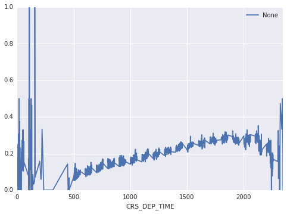

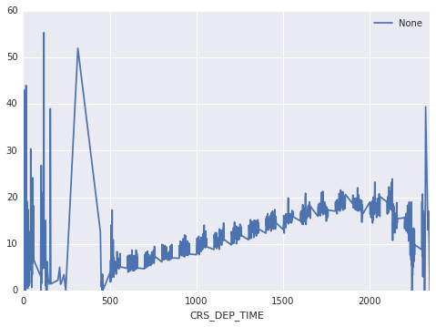

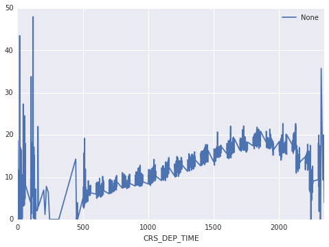

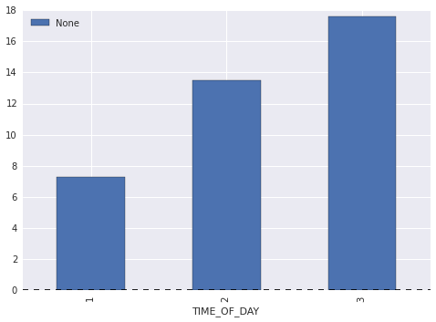

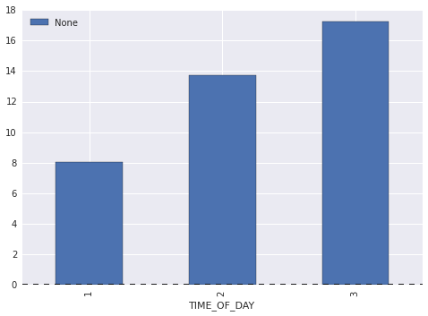

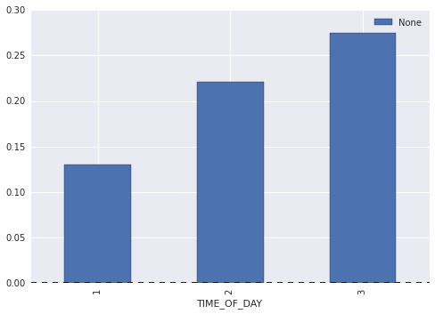

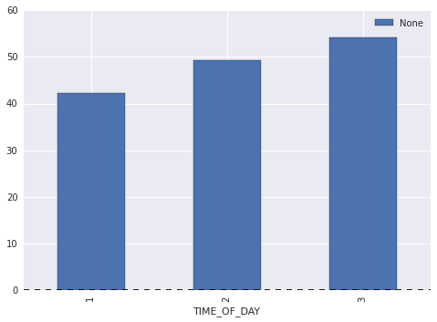

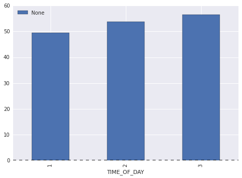

```python
#Group by departure time, find mean delay rate/amount delay
by_time = frm.groupby('CRS_DEP_TIME', as_index=False)

rate_time = by_time.aggregate(np.mean)
time_data = rate_time[['CRS_DEP_TIME', 'DEP_DELAY_NEW', 'ARR_DELAY_NEW', 'DELAYED']]

#Plot delay rate / amount of delay by departure time
time_data.plot('CRS_DEP_TIME', 'DELAYED')
time_data.plot('CRS_DEP_TIME', 'DEP_DELAY_NEW')
time_data.plot('CRS_DEP_TIME', 'ARR_DELAY_NEW')

#Group by time of day, find mean delay rate/amount delay
by_time_day = test.groupby('TIME_OF_DAY', as_index=False)
rate_time_day = by_time_day.aggregate(np.mean)

#Plot delay rate / amount of delay by time of day
time_day_data = rate_time_day[['TIME_OF_DAY', 'DEP_DELAY_NEW', 'ARR_DELAY_NEW', 'DELAYED']]
time_day_data.plot('TIME_OF_DAY', 'DEP_DELAY_NEW', kind='bar')
time_day_data.plot('TIME_OF_DAY', 'ARR_DELAY_NEW', kind='bar')
time_day_data.plot('TIME_OF_DAY', 'DELAYED', kind='bar')

#Group by time of day -- delayed flights only
by_time_day_delay = test_delayed.groupby('TIME_OF_DAY', as_index=False)
rate_time_day_delay = by_time_day_delay.aggregate(np.mean)

#Plot amount of delay by time of day -- delayed flights only
time_day_data_delay = rate_time_day_delay[['TIME_OF_DAY', 'DEP_DELAY_NEW', 'ARR_DELAY_NEW', 'DELAYED']]
time_day_data_delay.plot('TIME_OF_DAY', 'DEP_DELAY_NEW', kind='bar')
time_day_data_delay.plot('TIME_OF_DAY', 'ARR_DELAY_NEW', kind='bar')
```

```python
time_data.head()
```

|  | CRS_DEP_TIME | DEP_DELAY_NEW | ARR_DELAY_NEW | DELAYED |
| --- | --- | --- | --- | --- |
| 0 | 1 | 16.166667 | 18.666667 | 0.250000 |
| 1 | 3 | 10.333333 | 8.500000 | 0.083333 |
| 2 | 4 | 0.000000 | 0.000000 | 0.000000 |
| 3 | 5 | 7.674591 | 7.184250 | 0.123328 |
| 4 | 6 | 43.000000 | 11.000000 | 0.000000 |

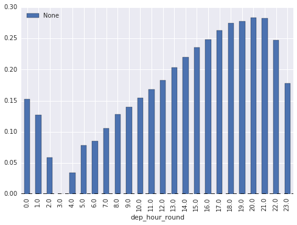

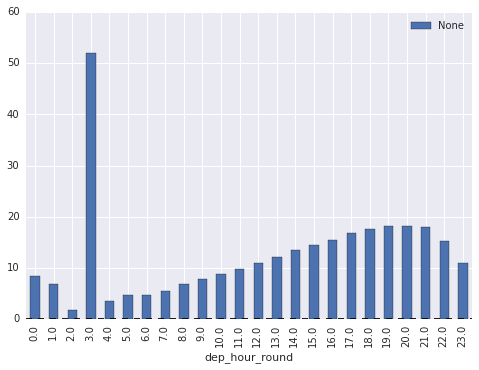

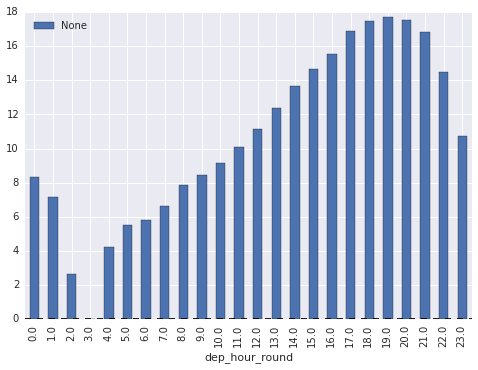

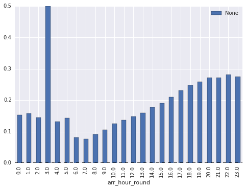

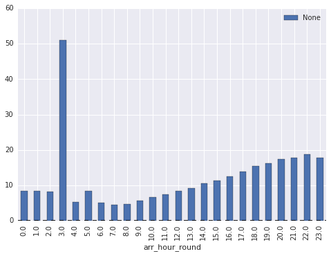

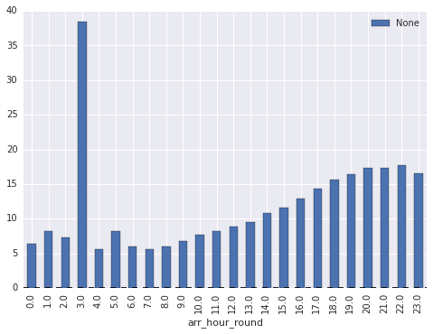

```python
#Group by ROUNDED departure time, find mean delay rate/amount delay (unconditional)
by_round_deptime = frm.groupby('dep_hour_round', as_index=False)

rate_deptime = by_round_deptime.aggregate(np.mean)
deptime_data = rate_deptime[['dep_hour_round', 'DEP_DELAY_NEW', 'ARR_DELAY_NEW', 'DELAYED']]

#Plot delay rate / amount of delay by departure time
deptime_data.plot('dep_hour_round', 'DELAYED', kind='bar')
deptime_data.plot('dep_hour_round', 'DEP_DELAY_NEW', kind='bar')
deptime_data.plot('dep_hour_round', 'ARR_DELAY_NEW', kind='bar')

#Group by ROUNDED arrival time, find mean delay rate/amount delay (unconditional)
by_round_arrtime = frm.groupby('arr_hour_round', as_index=False)

rate_arrtime = by_round_arrtime.aggregate(np.mean)
arrtime_data = rate_arrtime[['arr_hour_round', 'DEP_DELAY_NEW', 'ARR_DELAY_NEW', 'DELAYED']]

#Plot delay rate / amount of delay by arrival time
arrtime_data.plot('arr_hour_round', 'DELAYED', kind='bar')
arrtime_data.plot('arr_hour_round', 'DEP_DELAY_NEW', kind='bar')
arrtime_data.plot('arr_hour_round', 'ARR_DELAY_NEW', kind='bar')
```

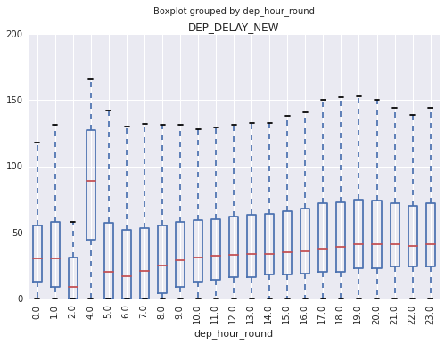

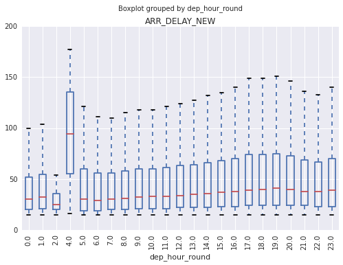

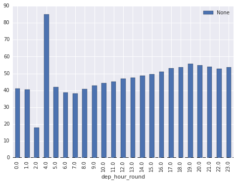

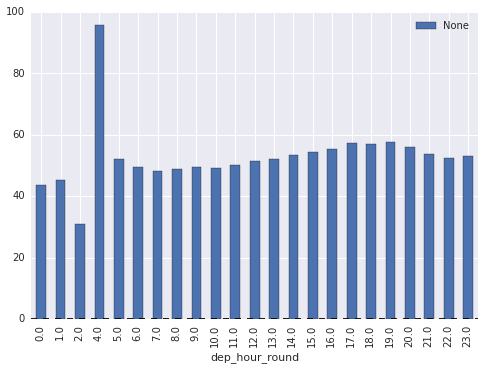

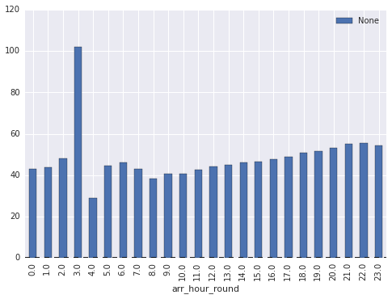

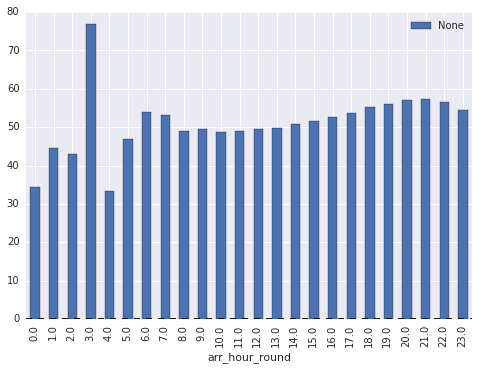

```python
#Plot amount of delay vs. hour (conditional on flight being delayed)
test_delayed.boxplot(column='DEP_DELAY_NEW', by='dep_hour_round')
plt.xticks(rotation=90)

test_delayed.boxplot(column='ARR_DELAY_NEW', by='dep_hour_round')
plt.xticks(rotation=90)

#Group by ROUNDED departure time, find mean delay rate/amount delay (conditional)
by_round_delaydeptime = test_delayed.groupby('dep_hour_round', as_index=False)

rate_delaydeptime = by_round_delaydeptime.aggregate(np.mean)
deptimedelay_data = rate_delaydeptime[['dep_hour_round', 'DEP_DELAY_NEW', 'ARR_DELAY_NEW', 'DELAYED']]

#Plot amount of delay by departure time
deptimedelay_data.plot('dep_hour_round', 'DEP_DELAY_NEW', kind='bar')
deptimedelay_data.plot('dep_hour_round', 'ARR_DELAY_NEW', kind='bar')

#Group by ROUNDED arrival time, find mean delay rate/amount delay (conditional)
by_round_delayarrtime = test_delayed.groupby('arr_hour_round', as_index=False)

rate_delayarrtime = by_round_delayarrtime.aggregate(np.mean)
arrtimedelay_data = rate_delayarrtime[['arr_hour_round', 'DEP_DELAY_NEW', 'ARR_DELAY_NEW', 'DELAYED']]

#Plot amount of delay by arrival time
arrtimedelay_data.plot('arr_hour_round', 'DEP_DELAY_NEW', kind='bar')
arrtimedelay_data.plot('arr_hour_round', 'ARR_DELAY_NEW', kind='bar')
```

Discussion: We see that flight delay follows generally the same trend for the rounded flight departure times as we observed for time of day. That is, later flights generally follow a smooth trend of increased likelihood of flight delay. One outlier in this trend is the flight time of around 3 - 4 AM -- this is not likely because this time actually has a higher rate of delayed flights, but rather may be due to the fact that there are not many flights at this time. As such, the delayed flights at this time may be overemphasized when taking the mean of delay rate and amount of delay. In general, looking at the time of flight seems to give a fairly good indication of how the flight will perform compared to other flights.

# Precipitation

Next, we move on to looking at weather data. First, we will examine precipitation (in our dataset, this is 'liquidOne', which represents the amount in hundredths of inches of precipitatation one hour prior to the flight time). Initially, we simply use precipitation as it is given in the data, but we find later on that it is more informative to create categories or "buckets" for precipitation data, similarly to how we grouped time of day earlier.

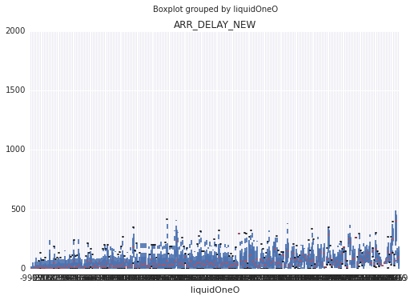

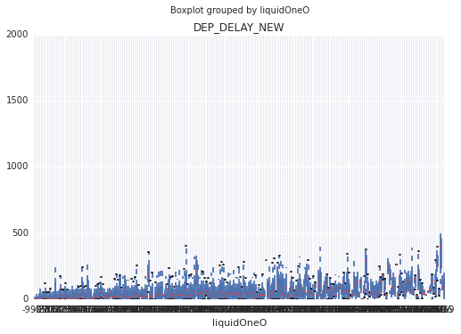

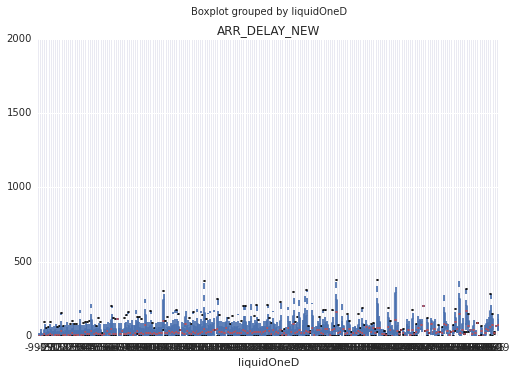

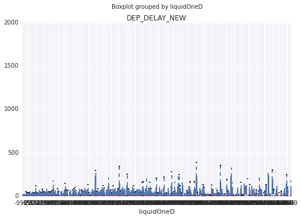

[figure not shown]

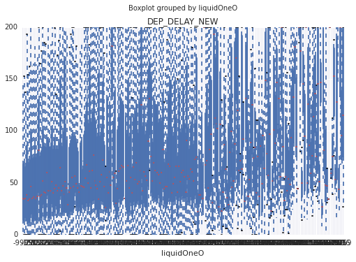

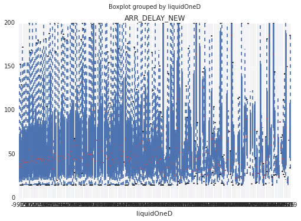

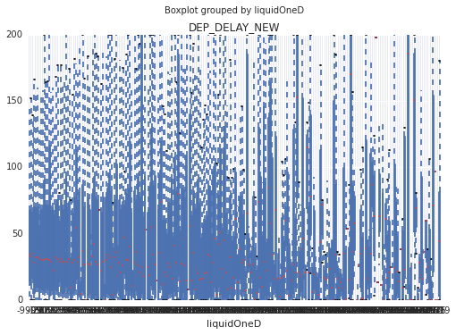

```python
#Based on liquidone (precipitation)
#Note: this was before we grouped precipitation into categories,
#not very easy to interpret/ not informative because of such a wide range of values -- no easily visible trends

#Plot delay (unconditional: arr_delay, dep_delay) vs. liquidoneD/O -- boxplot
frm.boxplot(column='ARR_DELAY_NEW', by='liquidOneO')
frm.boxplot(column='DEP_DELAY_NEW', by='liquidOneO')

frm.boxplot(column='ARR_DELAY_NEW', by='liquidOneD')
frm.boxplot(column='DEP_DELAY_NEW', by='liquidOneD')

#Plot conditional on delay (delayed flights only) -- arr_delay, dep_delay grouped by liquidoneD/O -- boxplot
test_delayed.boxplot(column='DEP_DELAY_NEW', by='liquidOneO')

test_delayed.boxplot(column='ARR_DELAY_NEW', by='liquidOneD')
test_delayed.boxplot(column='DEP_DELAY_NEW', by='liquidOneD')
```

```python
#Split liquid (precipitation -- origin) into categories (low, moderate, high)
col = test[['liquidOneO']]
REALLY_LOW = (col>=0) & (col<=5)
LOW = (col>5) & (col<=40)
MODERATE  = (col>40) & (col<=80)
MODERATE_HIGH = (col>80) & (col<=200)
HIGH   = (col>200)
rslt2 = REALLY_LOW.applymap(lambda x: 1 if x else 0) + 2*LOW.applymap(lambda x: 1 if x else 0) + 3*MODERATE.applymap(lambda x: 1 if x else 0) + 4*MODERATE_HIGH.applymap(lambda x: 1 if x else 0) + 5*HIGH.applymap(lambda x: 1 if x else 0)
```